# Single-Cell Multi-Omics Analysis

Rick Chang

2023-04-20

```r
# install.packages("Seurat")
# install.packages("ggplot2")
library(Seurat)
library(SeuratData)
library(cowplot)
library(dplyr)
library(ggplot2)
set.seed(2023)
```

# Loading data

We use the CITE-seq dataset from (Stuart, Butler et al., Cell 2019), which consists of 30,672 cells. The object contains two assays, RNA and antibody-derived tags (ADT).  
- RNA: 17,009 features (genes)  
- ADT: 25 features (antibodies)

```r
# Load a Seurat object which contains the RNA and ADT assays.
InstallData("bmcite")
cite <- LoadData(ds = "bmcite")
```

We would only use 5,000 cells with specific cell types such as “CD4”, “CD8”, “DC”, and “CD14”. Those are what we show in the lecture.  
**Note**: In order to demonstrate the performance of multi-omics integration, we have the cell type information in this dataset. However, we usually don’t have that information in the real data.

```r
# Only demo few cell types
target.celltype <- c("CD8 Naive", "CD4 Naive", "Naive B",
                     "cDC2", "pDC", "CD14 Mono", "CD56 bright NK")
target.idx <- which(cite$celltype.l2 %in% target.celltype)
cite <- cite[, target.idx]
# down-sample the larger dataset to 5000 samples
cite <- cite[, sample(1:ncol(cite), 5000)]
cite@assays
#View(cite@assays[["RNA"]]@counts[1:50,1:50]  %>% as.matrix())
#View(cite@assays[["ADT"]]@counts[1:25,1:50]  %>% as.matrix())
```

```
## $RNA
## Assay data with 17009 features for 5000 cells
## Top 10 variable features:
##  IGKC, HBA2, HBB, HBA1, IGHA1, IGLC2, JCHAIN, HBM, IGHG1, IGHM
##
## $ADT
## Assay data with 25 features for 5000 cells
## Top 10 variable features:
##  CD11a, CD11c, CD123, CD127-IL7Ra, CD14, CD16, CD161, CD19, CD197-CCR7,
## CD25
```

## Data pre-processing

Due to the inherent levels of noise in single-cell RNA-seq, techniques such as PCA are often used to reduce the dimensionality of the dataset. We then perform pre-processing on both assays by using standard pipelines in Seurat which include normalization, feature selection, and dimensional reduction with PCA.

```r
# (1) scRNA
DefaultAssay(cite) <- 'RNA'
cite <- NormalizeData(cite) %>%
  FindVariableFeatures() %>%
  ScaleData() %>%
  RunPCA(reduction.name = 'pca')

# (2) ADT
# set dimensional reduction name as "apca" to avoid overwriting the PCA result of scRNASeq
DefaultAssay(cite) <- 'ADT'
VariableFeatures(cite) <- rownames(cite[["ADT"]])
cite <- NormalizeData(cite, normalization.method = 'CLR', margin = 2) %>%
  ScaleData() %>%
  RunPCA(reduction.name = 'apca')
```

# scRNA data

First, we analyze the scRNA in the CITE-Seq data and visualize clustering result on the UMAP plot.

Three-step analysis:  
(1) Calculate closest neighbors  
(2) Create a UMAP visualization  
(3) Perform graph-based clustering

## Cluster scRNA data

After preprocessing and dimension reduction, for each cell, we calculate its closest neighbors based on the first 30 PCs. Then, we create a UMAP visualization of the data, and perform clustering and visualize these results on the UMAP plot.

```r
# UMAP visualization and clustering based only on RNA data
DefaultAssay(cite) <- "RNA"
# Step 1
cite <- FindNeighbors(cite, dims = 1:30, reduction = 'pca')
# Step 2
cite <- RunUMAP(cite, reduction = 'pca', dims = 1:30, assay = 'RNA',
                reduction.name = 'rna.umap', reduction.key = 'rnaUMAP_')
# Step 3
cite <- FindClusters(cite, resolution = 2, graph.name = 'RNA_snn')
```

```
## Modularity Optimizer version 1.3.0 by Ludo Waltman and Nees Jan van Eck
##
## Number of nodes: 5000
## Number of edges: 243139
##
## Running Louvain algorithm...
## Maximum modularity in 10 random starts: 0.6480
## Number of communities: 13
## Elapsed time: 1 seconds
```

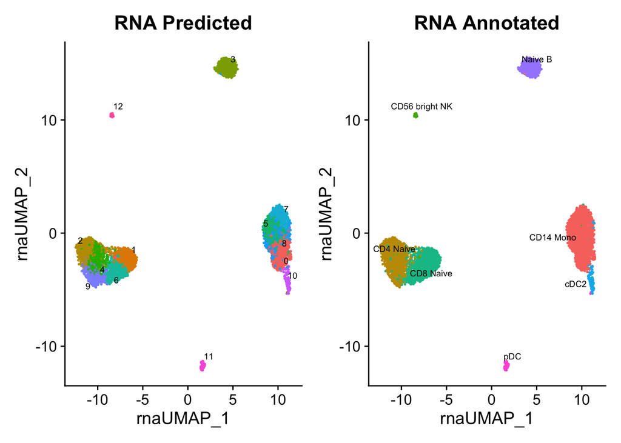

```r
cite$rna_clusters <- Idents(cite)

# Dimensional reduction plot
p1 <- DimPlot(cite, reduction = 'rna.umap',
              label = TRUE, repel = TRUE, label.size = 2.5) +
      ggtitle("RNA Predicted")
p2 <- DimPlot(cite, reduction = 'rna.umap', group.by = 'celltype.l2',
              label = TRUE, repel = TRUE, label.size = 2.5) +
      ggtitle("RNA Annotated")
p1+p2 & NoLegend() & theme(plot.title = element_text(hjust = 0.5))
```

# Surface protein data (ADT)

In CITE-seq, we not only have RNA data, but also have ADT data for the same cell. Then, we can analyze ADT data in a similar way as RNA data.

Three-step analysis:  
(1) Calculate closest neighbors  
(2) Create a UMAP visualization  
(3) Perform graph-based clustering

## Cluster surface protein data (ADT)

```r
# Step 1
cite <- FindNeighbors(cite, dims = 1:18, reduction = 'apca')
# Step 2
cite <- RunUMAP(cite, reduction = 'apca', dims = 1:18, assay = 'ADT',
              reduction.name = 'adt.umap', reduction.key = 'adtUMAP_')
# Step 3
cite <- FindClusters(cite, resolution = 2, graph.name = 'ADT_snn')
```

```
## Modularity Optimizer version 1.3.0 by Ludo Waltman and Nees Jan van Eck
##
## Number of nodes: 5000
## Number of edges: 191091
##
## Running Louvain algorithm...
## Maximum modularity in 10 random starts: 0.6584
## Number of communities: 18
## Elapsed time: 0 seconds
```

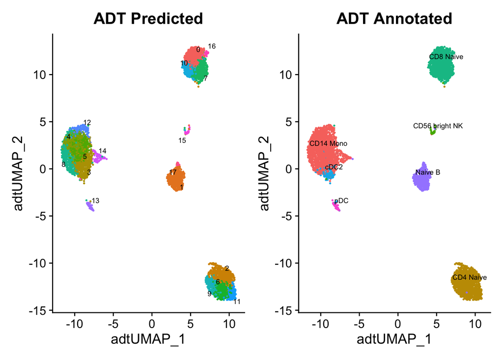

```r
cite$adt_clusters <- Idents(cite)

# Dimensional reduction plot
p3 <- DimPlot(cite, reduction = 'adt.umap',
              label = TRUE, repel = TRUE, label.size = 2.5) +
      ggtitle("ADT Predicted")
p4 <- DimPlot(cite, reduction = 'adt.umap', group.by = 'celltype.l2',
              label = TRUE, repel = TRUE, label.size = 2.5) +
      ggtitle("ADT Annotated")
p3+p4 & NoLegend() & theme(plot.title = element_text(hjust = 0.5))
```

# scRNA data + ADT data

In CITE-Seq, since we have RNA and ADT data for the same cell, we can apply weighted nearest neighbor (WNN) clustering method to integrate different omics.

## WNN Clustering

For each cell, we calculate its closest neighbors in the dataset based on a weighted combination of RNA and protein similarities.

Three-step analysis:  
(1) Calculate closest neighbors  
(2) Create a UMAP visualization  
(3) Perform graph-based clustering

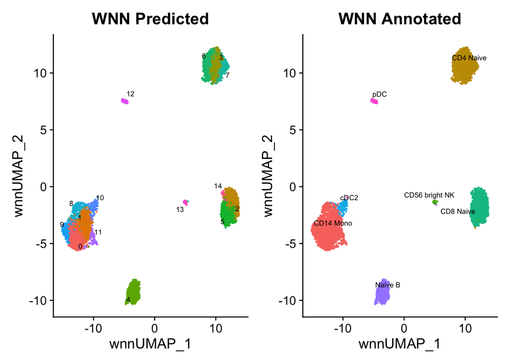

```r
# Step 1
cite <- FindMultiModalNeighbors(
  cite, reduction.list = list("pca", "apca"),
  dims.list = list(1:30, 1:18),
  modality.weight.name = c("RNA.weight", "ADT.weight"))
# Step 2
cite <- RunUMAP(cite, nn.name = "weighted.nn", reduction.name = "wnn.umap", reduction.key = "wnnUMAP_")
# Step 3
cite <- FindClusters(cite, graph.name = "wsnn", algorithm = 3, resolution = 2, verbose = FALSE)
cite$wnn_clusters <- Idents(cite)

# Dimensional reduction plot
p5 <- DimPlot(cite, reduction = 'wnn.umap',
              label = TRUE, repel = TRUE, label.size = 2.5) +
      ggtitle("WNN Predicted")
p6 <- DimPlot(cite, reduction = 'wnn.umap', group.by = 'celltype.l2',
              label = TRUE, repel = TRUE, label.size = 2.5) +
      ggtitle("WNN Annotated")
p5+p6 & NoLegend() & theme(plot.title = element_text(hjust = 0.5))
```

## Data comparison

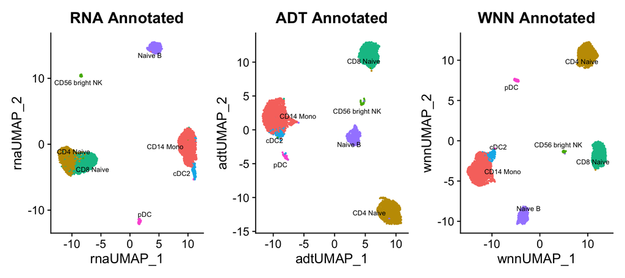

```r
p2+p4+p6 & NoLegend() & theme(plot.title = element_text(hjust = 0.5))
```

## Cell-specific modality weights

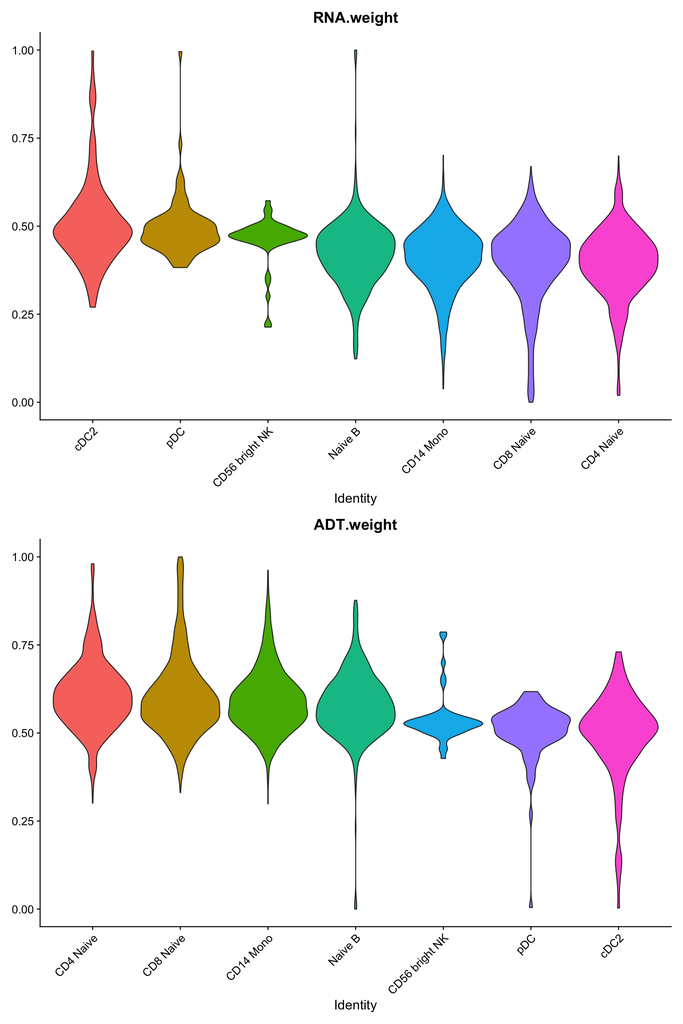

```r
VlnPlot(cite, features = c("RNA.weight", "ADT.weight"),
        group.by = 'celltype.l2', sort = TRUE,
        pt.size = 0, ncol = 1) + NoLegend()
```

Reference:  
https://satijalab.org/seurat/articles/weighted_nearest_neighbor_analysis.html